# Correlation Analysis

R Programming Basis

R Code Description for Correlation Analysis

Yeongeun Jeon  
07-15-2022

- **참고 : R과 통계분석(Tidyverse 활용), 박동련 저**

# **1. 상관분석(Correlation Analysis)**

> 두 `연속형` 변수 사이에 `선형적인 관계`가 존재하는지, 또한 존재한다면 어느 정도 강한 선형관계가 존재하는지를 파악하기 위한 통계적 분석방법을 `상관분석`이라고 한다. 여기서, 선형관계란, 한 변수가 증가하면 다른 한 변수도 증가 혹은 감소하는 관계를 의미한다. 상관분석에는 두 변수 사이의 선형관계 정도와 방향을 수치로 나타낸 상관계수(Correlation Coefficient)를 사용한다. 상관계수에는 대표적으로 피어슨 상관계수(Pearson Correlation Coefficient), 켄달 타우 계수(Kendall Tau Coefficient), 스피어만 상관계수(Spearman Correlation Coefficient)가 있다.

| 상관계수 | 설명 |
| --- | --- |
| 피어슨 | $\cdot$ 두 변수가 각각 간격/비율척도로 측정된 경우에 사용되는 상관계수 $\cdot$ 두 변수 중 적어도 한 변수는 정규성을 만족 |
| 켄달 타우 | $\cdot$ 피어슨 상관계수의 비모수 버전으로 두 변수가 서열로 측정된 경우에 사용되는 상관계수 |
| 스피어만 | $\cdot$ 피어슨 상관계수의 비모수 버전으로 두 변수가 서열로 측정된 경우에 사용되는 상관계수 |

※ 여기서는 두 변수가 정규분포를 따른다는 가정하에서 피어슨 상관계수에 대해서만 설명한다.

# **2. 산점도**

- 두 변수 사이에 상관관계가 존재하는 지를 알아보기 위해서 우선적으로 `산점도를 작성`하여 선형성을 확인해야 한다.
  - 즉, 두 변수의 대응되는 데이터들을 좌표평면에 점으로 표시하여 두 변수간의 관계를 대략적으로 파악한다.
  - 예를 들어, 두 변수 $X$와 $Y$의 산점도는 다음과 같은 형태로 나타나게 된다.
    - 그림 (a)와 같은 형태로 나타나는 경우는 한 변수의 값이 증가하면 다른 변수의 값도 증가하는 경향, 즉, 양의 상관(Positive Correlated)이 있는 것으로 판단할 수 있다.
    - 그림 (b)와 같은 형태로 나타나는 경우는 한 변수의 값이 증가하면 다른 변수의 값은 감소하는 경향, 즉, 음의 상관(Negative Correlated)이 있는 것으로 판단할 수 있다.
    - 그림 (c)와 같은 형태로 나타나는 경우는 두 변수 사이에 선형관계가 없는, 즉, 무상관(Uncorrelated)을 나타낸다.

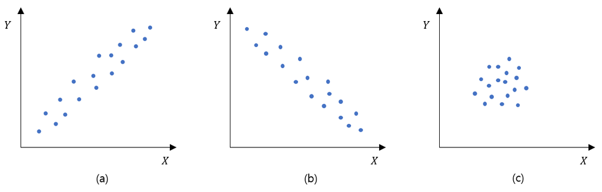

- 산점도를 작성하는 방법에는 R에서 기본적으로 제공하는 함수 `plot()`을 사용하거나 Package `ggplot2`에 내장된 함수 `geom_point()`를 사용하면 된다.

## **2-1. 함수 plot()**

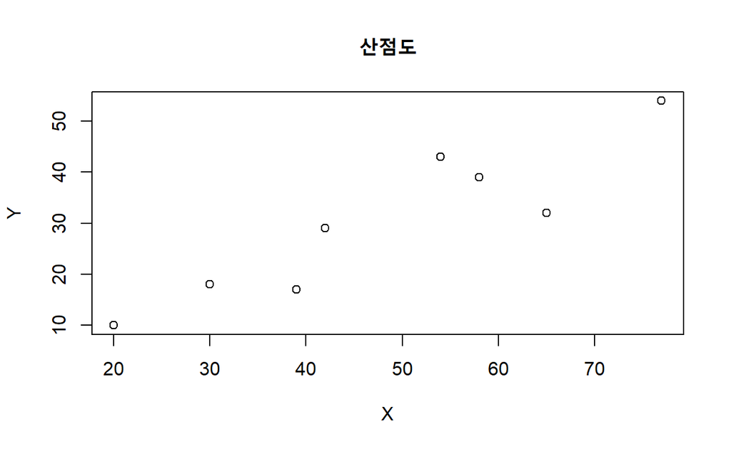

[output not shown]

`Result!` 변수 “x”가 증가할 때 변수 “y”도 같이 증가하는 선형관계가 보인다.

## **2-2. 함수 geom_point()**

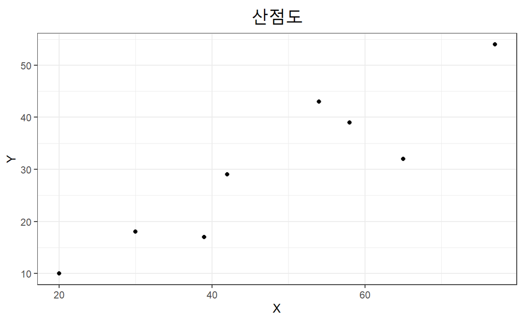

[output not shown]

`Result!` 변수 “x”가 증가할 때 변수 “y”도 같이 증가하는 선형관계가 보인다.

## **2-3. 산점도 행렬**

- 두 개 이상의 변수 사이의 산점도를 동시에 작성하여 함께 선형관계를 살펴볼 경우 산점도 행렬을 사용할 수 있다.
- 산점도 행렬은 함수 `plot()`와 Package `GGally`에 내장된 함수 `ggpairs()`를 통해 작성할 수 있다.

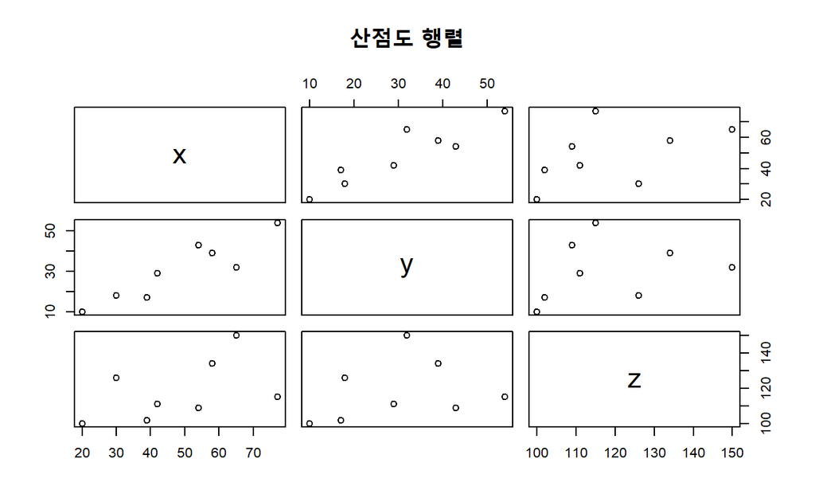

[output not shown]

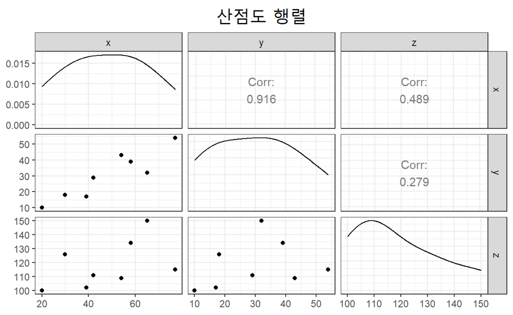

```
# Package GGally에 내장된 함수 ggpairs()
pacman::p_load("GGally")

ggpairs(df) +
  labs(title = "산점도 행렬") +
  theme_bw() +
  theme(plot.title = element_text(size=20, hjust = 0.5))
```

`Result!` 변수 “x”와 “y” 사이, 변수 “x”와 “z” 사이에는 양의 상관이 존재하는 것으로 보인다. 하지만, 변수 “y”와 “z” 사이에는 양의 상관과 무상관 중 정확한 판단을 하기 어렵다.

# **3. 상관계수**

- 두 변수의 산점도를 작성해보면 두 변수 사이에 선형관계가 존재하는지의 여부를 알 수 있으며, 선형관계가 존재하는 경우 어떠한 선형관계인지를 판단할 수 있다.
- 하지만, 산점도는 그래프로 표현하기 때문에 `대략적으로만 분석할 수 있다는 단점`이 있다.
- 따라서, 두 변수 사이에 존재하는 선형관계 정도를 더 정확하게 분석하기 위한 측도가 필요한데 이를 위해서 `상관계수가 사용`된다.
  - 즉, 상관계수는 두 변수 사이의 선형관계 정도를 나타낸 값이다.
  - 모집단에 대한 상관계수인 모상관계수는 $\rho$, 표본에 대한 상관계수인 표본상관계수는 $r$로 표시한다.
    - 모상관계수는 계산할 수 없기 때문에, 모상관계수의 추정치인 표본상관계수 $r$를 계산한다.
- 가장 많이 사용되는 상관계수는 피어슨 상관계수이며, 여기에서는 이 상관계수에 대해서만 설명한다.
  - $n$개의 관측값을 가지는 두 변수 $X$와 $Y$에 대한 피어슨 상관계수를 계산하는 방법은 식 (1)과 같다.
    $$\begin{align}
    r = \frac{S_{XY}}{\sqrt{S_{XX}}\sqrt{S_{YY}}} = \frac{\sum_{i=1}^{n}
    (X_i - \bar{X})(Y_i - \bar{Y})}{\sqrt{\sum_{i=1}^{n}(X_i -
    \bar{X})^2}\sqrt{\sum_{i=1}^{n}(Y_i - \bar{Y})^2}}
    \tag{1}
    \end{align}$$
    - $\bar{X}$와 $\bar{Y}$는 각각 변수 $X$와 $Y$의 표본평균을 의미한다.
  - 피어슨 상관계수는 공분산을 각 변수의 표준편차로 나누어 정의되기 때문에 `측정단위에 영향을 받지 않는다`.
- 표본상관계수 $r$은 다음과 같은 성질을 갖는다.
  1. 표본상관계수의 값은 항상 $-1\le r \le 1$이다.
  2. $0<r\le1$일 때 두 변수는 양의 상관관계를 가진다. → 한 변수가 증가하면 다른 변수도 증가하는 경향
  3. $-1\le r<0$일 때 두 변수는 음의 상관관계를 가진다. → 한 변수가 증가하면 다른 변수는 감소하는 경향
  4. $r=0$일 때, 두 변수는 선형적인 관계를 가지지 않는다. → 무상관
  5. $r=\pm1$일 때, 두 변수는 완전한 선형관계를 가진다.
  6. 두 변수의 선형관계가 강할수록 $r$은 $1$ 또는 $-1$에 가깝다.
  7. $r$의 절대값은 선형관계의 강도를 나타내며, $r$의 부호는 방향을 나타낸다.

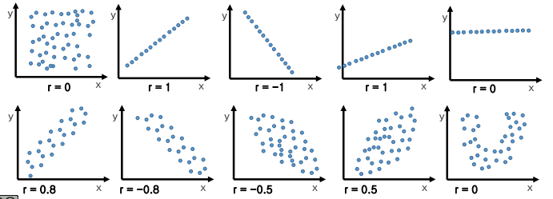

출처 : https://ybeaning.tistory.com/19

- 표본상관계수를 해석할 때 주의해야할 점은 다음과 같다.
  1. 상관계수는 직선의 기울기가 아니다.
     - 즉, $r=\pm1$이라고 해도 두 변수 사이의 기울기는 다양하다.
  2. 상관계수가 0이라는 것은 두 변수 사이에 선형관계가 없다는 것이지 관계가 없다는 것은 아니다.
  3. 상관계수가 높다고 해서 두 변수 사이에 반드시 인과관계(원인-결과)가 있는 것은 아니다.
     - 예를 들어, 아이스크림 판매량과 익사자 수는 양의 상관관계에 있다. 하지만, 아이스크림이 익사의 원인이 되는 것은 아니다. 왜냐하면, 여름의 더위가 양쪽 모두의 공통되는 원인이기 때문이다.

출처 : https://ko.wikipedia.org/wiki/%EC%83%81%EA%B4%80_%EB%B6%84%EC%84%9D

- 표본상관계수 $r$을 구하기 위해서는 함수 `cor(변수1, 변수2)`를 사용하면 된다.

[output not shown]

```
[1] 0.9163436
```

```
# 식 (1)
r <- sum( (x - mean(x))*(y - mean(y)) )/(sqrt( sum((x - mean(x))^2) )*sqrt( sum((y - mean(y))^2) ))
r
```

```
[1] 0.9163436
```

`Result!` 두 변수 “x”와 “y” 사이의 표본상관계수 $r=0.916$이며, 표본상관계수의 부호가 양이기 때문에 두 변수는 양의 상관관계를 가진다. 게다가, 표본상관계수의 값이 1에 매우 가까우므로, 두 변수 사이에는 강한 양의 상관관계가 있다고 할 수 있다.

[output not shown]

```
[1] 0.2787342
```

```
# 식 (1)
r <- sum( (y - mean(y))*(z - mean(z)) )/(sqrt( sum((y - mean(y))^2) )*sqrt( sum((z - mean(z))^2) ))
r
```

```
[1] 0.2787342
```

`Result!` 두 변수 “y”와 “z” 사이의 표본상관계수 $r=0.279$이며, 표본상관계수의 부호가 양이기 때문에 두 변수는 양의 상관관계를 가진다. 하지만, 표본상관계수의 값이 0에 가까우므로, 두 변수 사이에는 약한 양의 상관관계가 있다고 할 수 있다.

## **3-1. 상관행렬 그래프**

### **3-1-1. 함수 corrplot()**

- Package `corrplot`에 내장되어 있는 함수 `corrplot()`을 이용하면 상관행렬 그래프를 작성할 수 있으며 자세한 옵션은 [여기](https://www.rdocumentation.org/packages/corrplot/versions/0.92/topics/corrplot)를 참고한다.

```
pacman::p_load("corrplot")

x <- c(20, 65, 39, 42, 30, 54, 58, 77)
y <- c(10, 32, 17, 29, 18, 43, 39, 54)
z <- c(100, 150, 102, 111, 126, 109, 134, 115)

df <- data.frame(x = x, y = y, z = z)
cor <- cor(df)
cor
```

```
          x         y         z
x 1.0000000 0.9163436 0.4891900
y 0.9163436 1.0000000 0.2787342
z 0.4891900 0.2787342 1.0000000
```

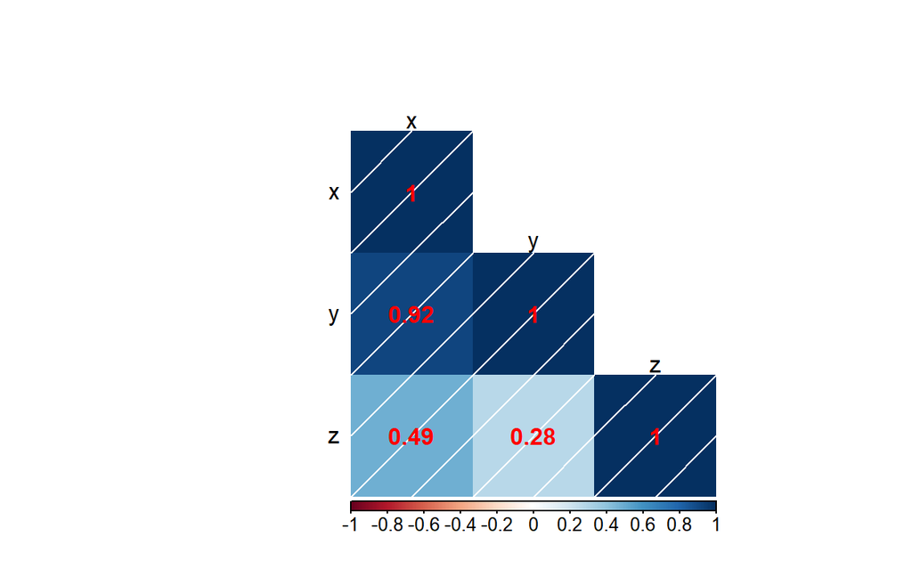

[output not shown]

### **3-1-2. 함수 ggcorr()**

- Package `GGally`에 내장되어 있는 함수 `ggcorr()`을 이용하면 상관행렬 그래프를 작성할 수 있으며 자세한 옵션은 [여기](https://www.rdocumentation.org/packages/GGally/versions/1.5.0/topics/ggcorr)를 참고한다.

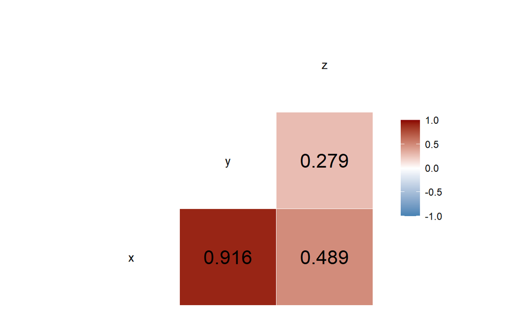

[output not shown]

# **4. 가설검정**

- 표본데이터를 이용하여 계산되는 피어슨 상관계수 $r$의 값은 표본상관계수로 이 값을 이용하면, 모상관계수 $\rho$에 대한 검정을 할 수 있다.
- 모상관계수 $\rho$에 대한 가설검정은 다음과 같은 단계로 수행한다.
  1. 가설설정
     - 귀무가설 $H_0 : \rho = 0$ vs 대립가설 $H_1 : \rho \ne 0$
       - 귀무가설은 “두 변수 사이에 선형관계가 존재하지 않는다.”이고 대립가설은 “두 변수 사이에 선형관계가 존재한다.”이다.
  2. 유의수준 $\alpha$ 결정
  3. 검정통계량 $T$ 계산
     - $T = r\sqrt{\frac{n-2}{1-r^2}} \sim t(n-2)$
       - $T$는 피어슨 상관계수에 대한 검정통계량이다.
       - 관측값에 의해 계산된 검정통계량 값은 $t$이다.
  4. 기각역 $R$ 설정
     - $R : |T|\ge t_{\alpha/2}(n-2)$
  5. 유의확률 $p-$값 계산
     - $p-$값 : $2P(T>t)$
  6. 가설의 기각 여부 결정
     - $|t|\ge t_{\alpha/2}(n-2)$ 또는 $p-값<\alpha$ → 귀무가설 $H_0$ 기각 → 두 변수 사이에 선형관계가 존재한다.
- 가설검정을 통해 상관계수가 통계적으로 유의한 의미를 가지는 지 파악할 수 있다.
- R에서 상관관계에 대한 가설검정을 수행하기 위해 함수 `cor.test(변수1, 변수2)`를 사용할 수 있다.

[output not shown]

```
    Pearson's product-moment correlation

data:  x and y
t = 5.6059, df = 6, p-value = 0.001373
alternative hypothesis: true correlation is not equal to 0
95 percent confidence interval:
 0.5974716 0.9849878
sample estimates:
      cor
0.9163436
```

`Result!` 두 변수 “x”와 “y”의 관측값으로 계산된 검정통계량 값 $t=5.6059$이며, $p-$값$=0.001373$이다. 이러한 결과를 바탕으로 유의수준 $\alpha=0.05$하에서 $p$-값은 $\alpha$보다 작기 때문에 귀무가설 $H_0$는 기각된다. 즉, 두 변수 “x”와 “y”의 상관계수는 통계적으로 유의하다고 할 수 있으며, 두 변수 사이에 선형관계가 존재한다.

[output not shown]

```
    Pearson's product-moment correlation

data:  y and z
t = 0.71093, df = 6, p-value = 0.5038
alternative hypothesis: true correlation is not equal to 0
95 percent confidence interval:
 -0.5300491  0.8219606
sample estimates:
      cor
0.2787342
```

`Result!` 두 변수 “y”와 “z”의 관측값으로 계산된 검정통계량 값 $t=0.71093$이며, $p-$값$=0.5038$이다. 이러한 결과를 바탕으로 유의수준 $\alpha=0.05$하에서 $p$-값은 $\alpha$보다 크기 때문에 귀무가설 $H_0$는 기각되지 않는다. 즉, 두 변수 “y”와 “z”의 상관계수는 통계적으로 유의하다고 할 수 없으며, 두 변수 사이에 선형관계는 존재하지 않는다.

# **5. 예제**

## **5-1. 예제1**

어떤 학급의 학생 9명을 대상으로 키(Height)와 몸무게(Weight)를 측정하여 다음의 결과를 얻었다.

| 키(cm) | 150 | 155 | 165 | 168 | 172 | 175 | 178 | 182 | 182 |
| --- | --- | --- | --- | --- | --- | --- | --- | --- | --- |
| 몸무게(kg) | 41 | 50 | 48 | 50 | 55 | 52 | 72 | 68 | 75 |

키와 몸무게에 대한 산점도를 작성하고 상관분석을 수행하여라.

```
height <- c(150, 155, 165, 168, 172, 175, 178, 182, 182)
weight <- c(41, 50, 48, 50, 55, 52, 72, 68, 75)

df <- data.frame(x = height, y = weight)
df
```

```
    x  y
1 150 41
2 155 50
3 165 48
4 168 50
5 172 55
6 175 52
7 178 72
8 182 68
9 182 75
```

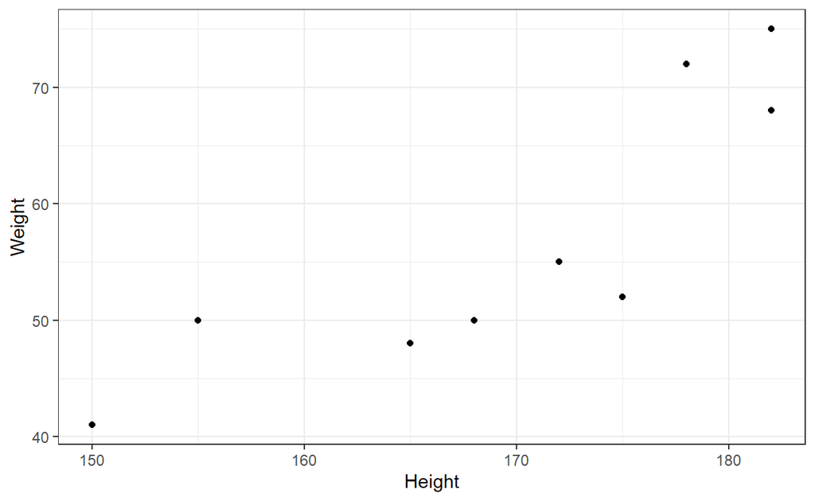

```
# 산점도도
pacman::p_load("ggplot2")

ggplot(df, aes(x = x, y = y)) +
  geom_point() +
  labs(x = "Height", y = "Weight") +
  theme_bw()
```

`Result!` 키와 몸무게 사이에 양의 상관이 있는 것으로 보인다.

```
# 상관계수
cor(height, weight, method = "pearson")
```

```
[1] 0.8519345
```

`Result!` 키와 몸무게 사이의 표본상관계수는 $r=0.852$이며, 강한 양의 상관관계가 존재한다.

```
# 가설검정검정
cor.test(height, weight, method = "pearson", alternative = "two.sided")
```

```
    Pearson's product-moment correlation

data:  height and weight
t = 4.3044, df = 7, p-value = 0.003547
alternative hypothesis: true correlation is not equal to 0
95 percent confidence interval:
 0.4325374 0.9682384
sample estimates:
      cor
0.8519345
```

`Result!` 키와 몸무게의 관측값으로 계산된 검정통계량 값 $t=4.3044$이며, $p$-값$=0.003547$이다. 이러한 결과를 바탕으로 유의수준 $\alpha=0.05$하에서 $p$-값은 $\alpha$보다 작기 때문에 귀무가설 $H_0$는 기각된다. 즉, 키와 몸무게의 상관계수는 통계적으로 유의하다고 할 수 있으며, 두 변수 사이에 선형관계는 존재한다.

## **5-2. 예제2**

각성제의 사용량과 각성제를 투여받은 피설험자가 청각신호에 반응하는 데 걸리는 시간과의 관계를 연구하는 실험에서 다음의 데이터를 얻었다.

[output not shown]

산점도를 작성하고 상관분석을 수행하여라,

```
mg  <- c(1, 3, 4, 7, 9, 12, 13, 14)
sec <- c(3.5, 2.1, 2.1, 1.3, 1.2, 2.2, 2.6, 4.2)

df <- data.frame(x = mg, y = sec)
df
```

```
   x   y
1  1 3.5
2  3 2.1
3  4 2.1
4  7 1.3
5  9 1.2
6 12 2.2
7 13 2.6
8 14 4.2
```

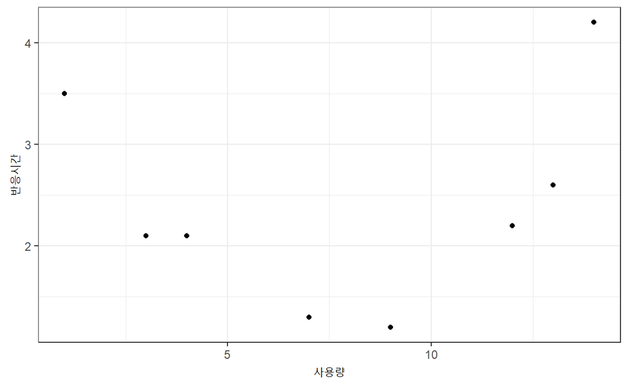

[output not shown]

`Result!` 각성제의 사용량과 반응시간은 선형관계가 없는 것으로 보인다.

```
# 상관계수
cor(mg, sec, method = "pearson")
```

```
[1] 0.1673518
```

`Result!` 각성제의 사용량과 반응시간 사이의 표본상관계수는 $r=0.167$이며, 약한 양의 상관관계가 존재한다.

```
# 가설검정검정
cor.test(mg, sec, method = "pearson", alternative = "two.sided")
```

```
    Pearson's product-moment correlation

data:  mg and sec
t = 0.41579, df = 6, p-value = 0.692
alternative hypothesis: true correlation is not equal to 0
95 percent confidence interval:
 -0.6091581  0.7800364
sample estimates:
      cor
0.1673518
```

`Result!` 각성제의 사용량과 반응시간의 관측값으로 계산된 검정통계량 값 $t=0.41579$이며, $p$-값$=0.692$이다. 이러한 결과를 바탕으로 유의수준 $\alpha=0.05$하에서 $p$-값은 $\alpha$보다 크기 때문에 귀무가설 $H_0$는 기각되지 않는다. 즉, 각성제의 사용량과 반응시간의 상관계수는 통계적으로 유의하다고 할 수 없으며, 두 변수 사이에 선형관계는 존재하지 않는다.

## **5-3. 예제3**

R에 내장되어 있는 데이터 “mtcars”는 1974년 Motor Trend US magazine에서 추출할 것으로 1973년, 1974년 모델의 32개 자동차들의 디자인과 성능을 비교한 것이다. 11개의 변수들 중 변수 “mpg” (연비)와 “disp” (배기량) 사이의 산점도를 작성하고 상관분석을 수행하여라.

```
data(mtcars)

ex3 <- mtcars
ex3
```

```
                     mpg cyl  disp  hp drat    wt  qsec vs am gear
Mazda RX4           21.0   6 160.0 110 3.90 2.620 16.46  0  1    4
Mazda RX4 Wag       21.0   6 160.0 110 3.90 2.875 17.02  0  1    4
Datsun 710          22.8   4 108.0  93 3.85 2.320 18.61  1  1    4
Hornet 4 Drive      21.4   6 258.0 110 3.08 3.215 19.44  1  0    3
Hornet Sportabout   18.7   8 360.0 175 3.15 3.440 17.02  0  0    3
Valiant             18.1   6 225.0 105 2.76 3.460 20.22  1  0    3
Duster 360          14.3   8 360.0 245 3.21 3.570 15.84  0  0    3
Merc 240D           24.4   4 146.7  62 3.69 3.190 20.00  1  0    4
Merc 230            22.8   4 140.8  95 3.92 3.150 22.90  1  0    4
Merc 280            19.2   6 167.6 123 3.92 3.440 18.30  1  0    4
Merc 280C           17.8   6 167.6 123 3.92 3.440 18.90  1  0    4
Merc 450SE          16.4   8 275.8 180 3.07 4.070 17.40  0  0    3
Merc 450SL          17.3   8 275.8 180 3.07 3.730 17.60  0  0    3
Merc 450SLC         15.2   8 275.8 180 3.07 3.780 18.00  0  0    3
Cadillac Fleetwood  10.4   8 472.0 205 2.93 5.250 17.98  0  0    3
Lincoln Continental 10.4   8 460.0 215 3.00 5.424 17.82  0  0    3
Chrysler Imperial   14.7   8 440.0 230 3.23 5.345 17.42  0  0    3
Fiat 128            32.4   4  78.7  66 4.08 2.200 19.47  1  1    4
Honda Civic         30.4   4  75.7  52 4.93 1.615 18.52  1  1    4
Toyota Corolla      33.9   4  71.1  65 4.22 1.835 19.90  1  1    4
Toyota Corona       21.5   4 120.1  97 3.70 2.465 20.01  1  0    3
Dodge Challenger    15.5   8 318.0 150 2.76 3.520 16.87  0  0    3
AMC Javelin         15.2   8 304.0 150 3.15 3.435 17.30  0  0    3
Camaro Z28          13.3   8 350.0 245 3.73 3.840 15.41  0  0    3
Pontiac Firebird    19.2   8 400.0 175 3.08 3.845 17.05  0  0    3
Fiat X1-9           27.3   4  79.0  66 4.08 1.935 18.90  1  1    4
Porsche 914-2       26.0   4 120.3  91 4.43 2.140 16.70  0  1    5
Lotus Europa        30.4   4  95.1 113 3.77 1.513 16.90  1  1    5
Ford Pantera L      15.8   8 351.0 264 4.22 3.170 14.50  0  1    5
Ferrari Dino        19.7   6 145.0 175 3.62 2.770 15.50  0  1    5
Maserati Bora       15.0   8 301.0 335 3.54 3.570 14.60  0  1    5
Volvo 142E          21.4   4 121.0 109 4.11 2.780 18.60  1  1    4
                    carb
Mazda RX4              4
Mazda RX4 Wag          4
Datsun 710             1
Hornet 4 Drive         1
Hornet Sportabout      2
Valiant                1
```

[output cut: 11 more lines]

```
Fiat 128               1
Honda Civic            2
Toyota Corolla         1
Toyota Corona          1
Dodge Challenger       2
AMC Javelin            2
Camaro Z28             4
Pontiac Firebird       2
Fiat X1-9              1
Porsche 914-2          2
Lotus Europa           2
Ford Pantera L         4
Ferrari Dino           6
Maserati Bora          8
Volvo 142E             2
```

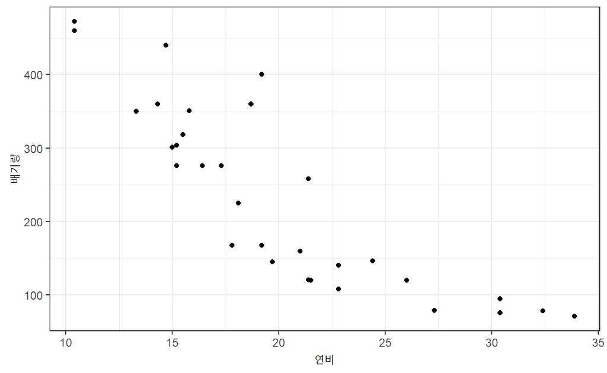

[output not shown]

`Result!` 연비와 배기량 사이에 음의 상관이 있는 것으로 보인다.

```
# 상관계수
cor(ex3$mpg, ex3$disp, method = "pearson")
```

```
[1] -0.8475514
```

`Result!` 연비와 배기량 사이의 표본상관계수는 $r=-0.848$이며, 강한 음의 상관관계가 존재한다.

```
# 가설검정검정
cor.test(ex3$mpg, ex3$disp, method = "pearson", alternative = "two.sided")
```

```
    Pearson's product-moment correlation

data:  ex3$mpg and ex3$disp
t = -8.7472, df = 30, p-value = 9.38e-10
alternative hypothesis: true correlation is not equal to 0
95 percent confidence interval:
 -0.9233594 -0.7081376
sample estimates:
       cor
-0.8475514
```

`Result!` 연비와 배기량의 관측값으로 계산된 검정통계량 값 $t=-8.7472$이며, $p$-값$=9.38e-10$이다. 이러한 결과를 바탕으로 유의수준 $\alpha=0.05$하에서 $p$-값은 $\alpha$보다 작기 때문에 귀무가설 $H_0$는 기각된다. 즉, 연비와 배기량의 상관계수는 통계적으로 유의하다고 할 수 있으며, 두 변수 사이에 선형관계는 존재한다.